# Line Intercept Riparian Survey 2 Relative Abundance

Oliver Franklin

2025-12-04

# Data import

For this script we import the tidied dataframe generated by the Data Wrangling script, which was exported to your output folder.

# Introduction

In our data analysis we distinguish *relative abundance* from *cover density*, and address these in separate scripts.

Relative abundance explores the composition of the transect by calculating the length occupied by each plant occurrence as a proportion of the total sum length of all plants recorded along the transect. Relative abundance is expressed as a unitless number or a percentage. We might ask, what proportion of vegetation along these transects is a hydrophytic/invasive/pioneer species? While very useful for understanding changes in vegetation, this metric does not provide insights into how much vegetation there is in absolute terms, so we cannot ask (e.g.,) whether vegetation is sparser in ‘reach a’ or ‘reach b’.

In contrast, cover density explores the length occupied by a particular plant (or non-plant) *per linear metre* of the transect. Here we express cover density as m/m. That is, the linear metre of the focal feature per linear metre of transect. We might ask, is vegetative cover in ‘reach a’ more dense than vegetative cover in ‘reach b’?

In separating the two concepts (amount of vegetation vs. composition of vegetation) the interpretation of generated statistics should be simplified. In this particular document, we focus on relative abundance only, which generates metrics that are independent of the length of the transect that was measured. Cover density metrics will be generated in the following document *Line Intercept Riparian Survey 3 Riparian Cover*. Ultimately you will probably want to consider both concepts and integrate the information we generate in order to better understand the vegetation at your site.

As always, careful consideration, and *a priori* hypotheses, should precede your analyses and interpretation.

## Plant Species Relative Abundance

For our analyses of relative abundance, we recommend omitting all of the non-plant features, which simplifies interpretation. It is fairly straightforward to interpret the percentage of vegetation occupied by a certain species, but gets more complicated if your percentage relates to all of the plants, substrates, etc. that you encountered. If you are interested in a particular non-plant feature (such as the amount of gravel bar that remains unvegetated) it is probably easiest to consider the cover densities in the next document.

We also recommend at this point excluding the extents of vegetation that overhang the channel (i.e., extend beyond the transect).

We default to excluding the non-plant values and overhanging vegetation, but this can be changed if you alter the code below:

```r
include_non_plants <- FALSE   # change to TRUE to keep the non-plant occurrences (Plant_codes starting with "!")
include_overhanging <- FALSE   # change to TRUE to keep overhanging extents of vegetation (negative Start_location values)
```

We start by considering the relative abundance for every species-height combination that was recorded in your surveys (i.e., you would get relative abundance for canopy redcedar, a separate relative abundance for seedling redcedar, etc.). Note that we generate relative abundance for each species-height combination in two separate ways:

1. As a proportion of all of the vegetation surveyed in that transect (adding vegetation from all height classes together); and
2. As a proportion of the height class in which that species-height combination was observed.

These different ‘denominators’ are interpreted in distinct ways, but both can be useful in tracking changes through time.

| Site | year | plant_code | Height_class | Transect_ID | proportion_of_all_veg | proportion_of_heightclass |
| --- | --- | --- | --- | --- | --- | --- |
| CONTROL | 2024 | ALNUS | C | 8 | 0.04669297396774729 | 0.1456632741155214 |
| CONTROL | 2024 | ALNUS | C | 2 | 0.02075940602344405 | 0.1069944045311733 |
| CONTROL | 2024 | ALNUS | C | 10 | 0.1157326422767271 | 1 |
| CONTROL | 2024 | ALNUS | C | 1 | 0.01167753582246813 | 1 |
| CONTROL | 2024 | ALNUS | C | 9 | 0.1473183740442638 | 1 |
| CONTROL | 2024 | ALNUS | C | 5 | 0.170081998528215 | 0.721881749221591 |
| CONTROL | 2024 | ALNUS | M | 1 | 1.454961259344919e-05 | 2.976467307885732e-05 |
| CONTROL | 2024 | CORNSER | M | 9 | 0.002575764067490116 | 0.008129222981200722 |
| CONTROL | 2024 | IMPAGLA | L | 2 | 0.01294799861936506 | 0.01724159888294726 |
| CONTROL | 2024 | IMPAGLA | L | 6 | 0.1514018968813143 | 0.1597600189502816 |

[output cut: 274 more lines]

To explore central tendency and variability at your focal reach, the following tables display the mean and standard deviation across all transects within a Site and year, for each plant species, which are again grouped by height class. We have presented two tables to distinguish the two denominators: all plants at a transect or all plants at a transect within the relevant height class.

Note that relative abundance across transects can be calculated in different ways. You could (a) sum the cover of a species across all transects, and then divide by the total cover summed across all transects. *Or*, (b) you could calculate relative abundance (species cover over total cover) for a species within each individual transect, and then take the mean of these values across transects. Below, and in the figures that follow, we do the latter (b). Our rationale is that:

- Your transects are treated as random samples drawn from a population of potential transects within your site. Method (a) implicitly treats transects as components of a complete census, and you probably did not sample exhaustively every patch of your site.
- We intentionally distinguish vegetation composition (relative abundance) from vegetation amount (cover density). Method (a) mixes these concepts. If there are large differences in the total amount of vegetation among transects (e.g., due to canopy layering or absence of growth on large alluvial deposits), these differences could have outsize impacts on the mean relative abundance values.

We highlight this difference because different methods handle this differently, not because we want you to get lost in the weeds (sorry about that). It may be helpful to consider these mean relative abundance values as indicators of how dominant particular species are at your site, on average across the range of plant densities you surveyed.

| Site | year | BankGroup | Height_class | plant_code | Mean_proportion_allveg | SD_proportion_allveg |
| --- | --- | --- | --- | --- | --- | --- |
| CONTROL | 2024 | Combined | L | IMPAGLA | 0.03138348556562022 | 0.05656851247192104 |
| CONTROL | 2024 | Combined | L | LYSIAME | 0.1626689692029733 | 0.1014020090847128 |
| CONTROL | 2024 | Combined | L | PHALARU | 0.4529547649032709 | 0.2748618526194584 |
| CONTROL | 2024 | Combined | L | ROSANUT | 0.00637777766872399 |  |
| CONTROL | 2024 | Combined | L | RUBUARM | 0.007194933283498029 | 0.01721593841907084 |
| CONTROL | 2024 | Combined | L | RUBUSPE | 0.0005373520043625477 |  |
| CONTROL | 2024 | Combined | L | SALIHOO | 0.0290991751323143 | 0.01875323945608707 |
| CONTROL | 2024 | Combined | L | SAMBRAC | 0.00125331521156817 |  |
| CONTROL | 2024 | Combined | L | TELLGRA | 0.001876519418540305 |  |
| CONTROL | 2024 | Combined | L | URTIGRA | 0.04210681896562229 | 0.01607570886198293 |

[output cut: 98 more lines]

| Site | year | BankGroup | Height_class | plant_code | Mean_proportion_heightclass | SD_proportion_heightclass |
| --- | --- | --- | --- | --- | --- | --- |
| CONTROL | 2024 | Combined | L | IMPAGLA | 0.04454756173490919 | 0.07012411781181731 |
| CONTROL | 2024 | Combined | L | LYSIAME | 0.2387019850395416 | 0.1518062667017697 |
| CONTROL | 2024 | Combined | L | PHALARU | 0.5799392627989918 | 0.2464660410020777 |
| CONTROL | 2024 | Combined | L | ROSANUT | 0.01220189600782357 |  |
| CONTROL | 2024 | Combined | L | RUBUARM | 0.009026761525548637 | 0.01328942289081458 |
| CONTROL | 2024 | Combined | L | RUBUSPE | 0.001028056106279913 |  |
| CONTROL | 2024 | Combined | L | SALIHOO | 0.03944104498748541 | 0.01988073258235314 |
| CONTROL | 2024 | Combined | L | SAMBRAC | 0.001668918787142582 |  |
| CONTROL | 2024 | Combined | L | TELLGRA | 0.002498779623141474 |  |
| CONTROL | 2024 | Combined | L | URTIGRA | 0.07094573338913582 | 0.1265967368676899 |

[output cut: 98 more lines]

The mean and sd values for species-height observations are useful for comparing how particular focal species have changed through time and with reference to a control site (where available). While very interesting to see how different species have changed, these summary statistics can be misleading if you scour through them and make speculative interpretations without *a priori* hypotheses. As such, we recommend you limit your interpretation of the above to the few species that you had specific (haha) expectations for.

The below figure may serve as a useful communication and interpretation tool. The values we display are means of species-height class relative abundance as a proportion of the transect’s total vegetation **in the relevant height class**, and correspond to the values presented in the table above. Note that we do not generate a figure for the species-height class occurrences as a proportion of **all vegetation per transect**, because this is less intuitive to interpret visually (if species-height is the numerator) or could obscure dominance for species spanning multiple height class (if species alone is the numerator).

Depending on the plant community at your sites, the following figure might look a bit overwhelming. While we display and export the stacked bar charts, we will also export to your output folder (but not display here) a series of bar charts that display the same data but may be a bit easier to interpret.

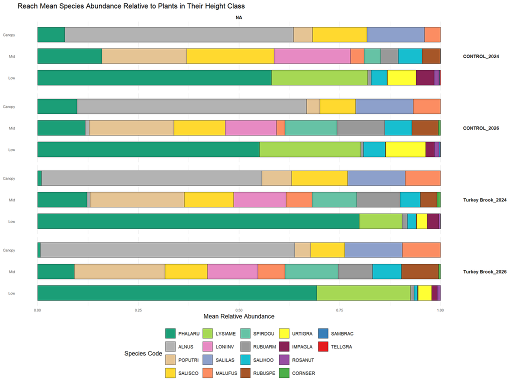

The above figure and tables can be useful in exploring changes in plant community at a species and height class level. However, to examine more general changes in the vegetative community we will generate diversity metrics, and later (in ‘Line Intercept Riparian Survey 4 Hydrophytes and More’) we will look at the changes in the abundance of vegetation that you classed as hydrophtic or invasive.

## Diversity Metrics: Simpson Index

We can calculate estimates of biodiversity using relative abundance. One example is a variation of the Simpson Diversity Index ($D$), which is calculated using the formula:

$$D = 1 - \sum \left( \frac{n_i \cdot
(n_i - 1)}{N \cdot (N - 1)} \right)$$

where: $n_i$ is the relative cover of the $i$-th species, and $N$ is the total cover per transect (all vegetation, across all height classes).

The value of $D$ ranges between 0 and 1: the greater the value, the greater the sample diversity.

Note that we have substituted relative cover (based on linear distances along our transect) for the ‘number of individuals’ that is typically used in a Simpson index. We calculate the Simpson index $D$ per transect (combining height classes) enabling us to calculate the mean and variance of $D$ for the focal reach, and will ultimately compare the distributions of $D$ values through the years and across sites. We do not calculate $D$ for individual height classes.

Although the denominator of our Simpson indices will comprise all vegetation at the relevant transect, we provide two versions of $D$: one with species-height combinations as the numerator, and one with just species as the numerator. We do this because it is often more intuitive to interpret or communicate when you are considering species diversity without the height component.

The interpretation of these two $D$ metrics will differ: If we consider (e.g.,) a canopy-height redcedar a different ‘type’ to an understory redcedar, it will be considered a different species in the Simpson formula, and the resulting $D$ values will be inflated relative to a dataset where we disregard height class and consider only ‘true’ species distinctions. For restoration projects it may be instructive to understand the functional differences among height classes within a species, or it may be irrelevant. The most important consideration is to ensure that, whichever approach you choose, you are consistent when comparing through time or across sites.

| Site | year | BankGroup | category | mean | sd |
| --- | --- | --- | --- | --- | --- |
| CONTROL | 2024 | All | Simpson D: Species Diversity | 0.586 | 0.241 |
| CONTROL | 2026 | All | Simpson D: Species Diversity | 0.598 | 0.23 |
| Turkey Brook | 2024 | All | Simpson D: Species Diversity | 0.516 | 0.209 |
| Turkey Brook | 2026 | All | Simpson D: Species Diversity | 0.649 | 0.131 |
| CONTROL | 2024 | All | Simpson D: Diversity of 'Species by Height Class' | 0.616 | 0.253 |
| CONTROL | 2026 | All | Simpson D: Diversity of 'Species by Height Class' | 0.623 | 0.245 |
| Turkey Brook | 2024 | All | Simpson D: Diversity of 'Species by Height Class' | 0.551 | 0.23 |
| Turkey Brook | 2026 | All | Simpson D: Diversity of 'Species by Height Class' | 0.669 | 0.138 |

Ensure you are interpreting the above metrics consistently: the diversity of ‘species by height class’ will be greater than that of species diversity because it incorporates both species distinctions and functional distinctions based on height of those plants. If this is confusing, we recommend focusing solely on the species diversity metrics, which may be more familiar and intuitive.

## Inferential Tests

If you have a control or reference site and multiple years of data, we can apply inferential statistical tests to see if the observed changes are likely to be due to chance variability, or are consistent with the expected effects of your restoration actions. We will test whether there are statistically significant changes in the Simpson diversity values using data from each transect grouped by Site and year, and we will also provide a method to test for significant changes in relative abundance for a given plant species.

You will be familiar with p values of 0.05 (observed result expected just due to chance 1 in 20 times) and we will use p=0.05 as our cut-off here. However, depending on your adaptive management plans, you may be willing to accept different levels of certainty, and p values of 0.1 are not unheard of in restoration projects. This all depends on the risk tolerance of you and your team, and should be established before conducting analyses.

Because the Simpson diversity values are bounded by 0 and 1, it is not appropriate to use ANOVA or simple linear models. We will use Beta regressions, which are capable of dealing with non-normal heteroscedastic data. Although Beta regressions cannot actually handle 0’s and 1’s, this will not be an issue because Simpson values of 1 would imply infinite diversity (Which we doubt you will have time to survey) and values of 0 would imply no diversity at all (which you would not need a metric to show you).

*NB* We provide these tests as a general framework, and caution against using them if you do not understand what the models are doing. We may not have an opportunity to refine them (changes in government priorities) but consider them a useful placeholder for now. We will apply Beta regressions based on what we expect the data to look like, however, actual data collected across a variety of ecosystems and stages of recovery might be very different, so we caution against taking the results at face value. If in doubt, our best advice is to rely on your own (and your restoration partners’) interpretation of the raw data and the figures we have already presented above.

The tests are carried out below, after we specify the before and after data that you wish to compare.

#### Before / After Years

Enter your before and after years in the below code, you may have more than one year in each category. Remember that these should balance (equal number of years before as after), but they need not be consecutive years. If you do not have balanced data (e.g., only one year was possible before project implementation) be very cautious in running and interpreting the tests. You could select only a subset of your data to keep the comparison balanced, but if you do this for more than one set of dates you must account for the multiple comparisons inflating the likelihood of a Type I error (false positive).

```r
# Define "Before" and "After" years
before_years <- c(2024) #add more years inside brackets if needed, e.g. 'c(2024, 2025, 2026)'
after_years <- c(2026) #add more years inside brackets if needed, e.g. 'c(2027, 2029, 2036)'
```

For our inferential test we will first generate a frequency plot of the data, then fit the Beta regression, and then plot the frequency distribution of the residuals (which should be broadly symmetrical around zero) and their relationships to the fitted values (for which no clear relationship or heteroscedasticity should be evident). If the diagnostics that are generated look reasonable, it is probably safe to interpret the outputs of the regression, which we explain below. We will export the results of the Beta regression to your output folder.

We will run the test both for the simpson dataframe (where we examined species, combining height) and the simpsonheight dataframe (where different height classes of the same species were considered distinct types).

### Simpson Diversity Index: Beta Regression

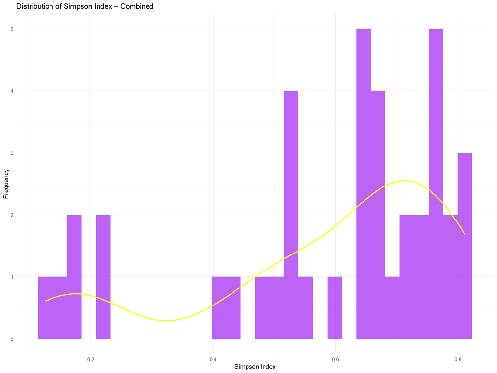

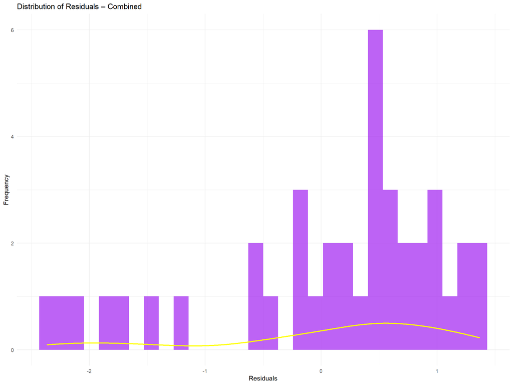

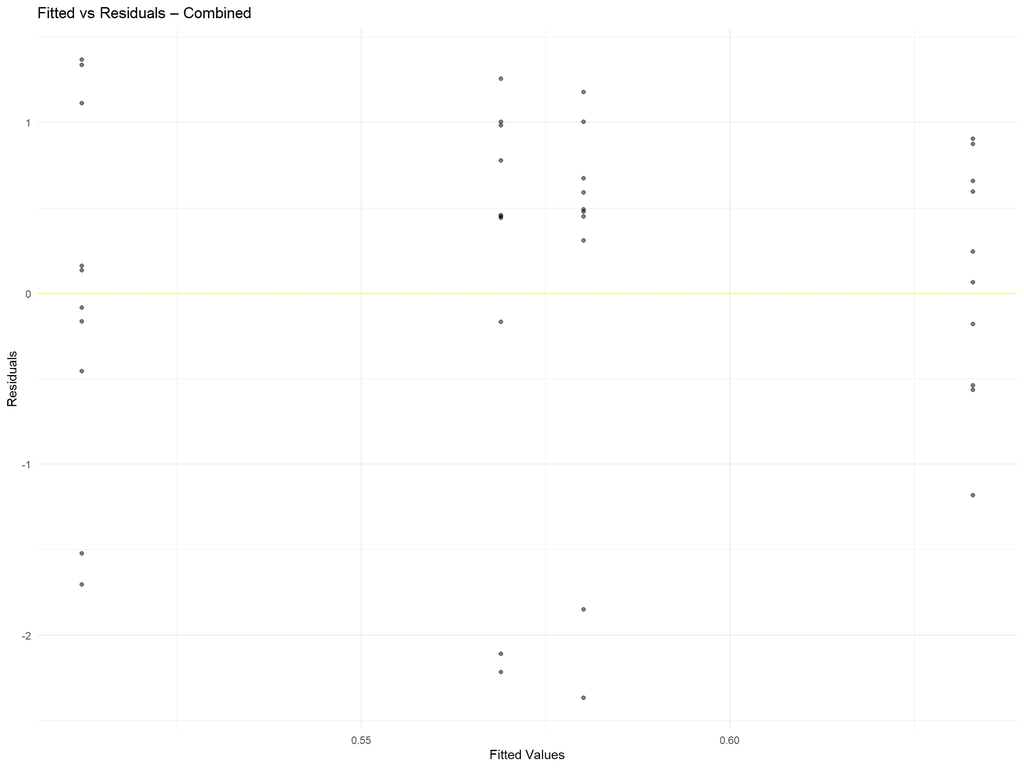

```
##
## Call:
## betareg(formula = simpson_index ~ Site * Time_Category, data = simpson.unround)
##
## Quantile residuals:
##     Min      1Q  Median      3Q     Max
## -2.4919 -0.2794  0.3591  0.7064  1.3177
##
## Coefficients (mean model with logit link):
##                                      Estimate Std. Error z value Pr(>|z|)
## (Intercept)                           0.32340    0.24623   1.313    0.189
## SiteTurkey Brook                      0.22140    0.35039   0.632    0.527
## Time_CategoryBefore                  -0.04579    0.34742  -0.132    0.895
## SiteTurkey Brook:Time_CategoryBefore -0.45059    0.49271  -0.915    0.360
##
## Phi coefficients (precision model with identity link):
##       Estimate Std. Error z value Pr(>|z|)
## (phi)    5.605      1.161   4.829 1.37e-06 ***
## ---
## Signif. codes:  0 '***' 0.001 '**' 0.01 '*' 0.05 '.' 0.1 ' ' 1
##
## Type of estimator: ML (maximum likelihood)
## Log-likelihood: 10.64 on 5 Df
## Pseudo R-squared: 0.05146
## Number of iterations: 18 (BFGS) + 2 (Fisher scoring)
```

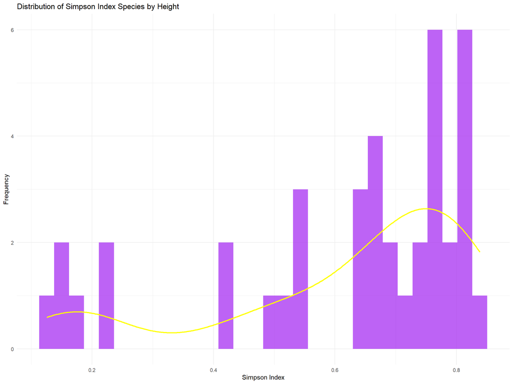

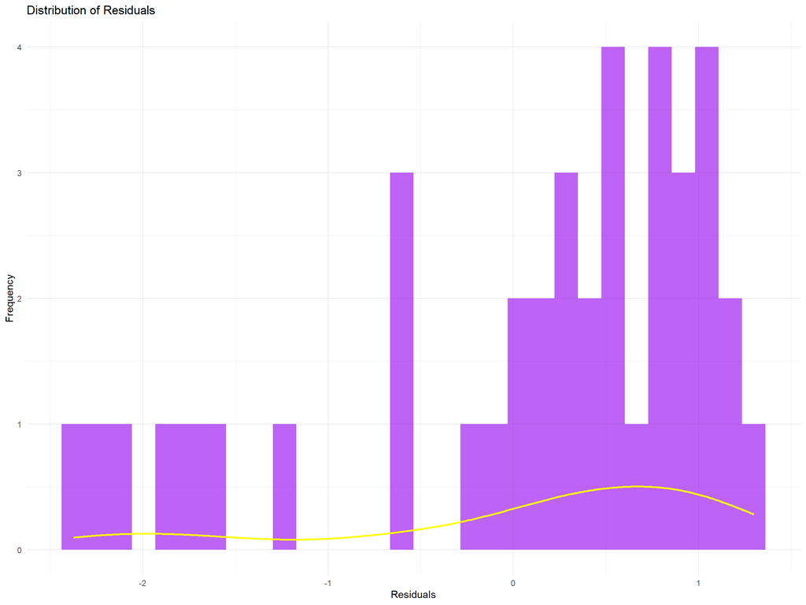

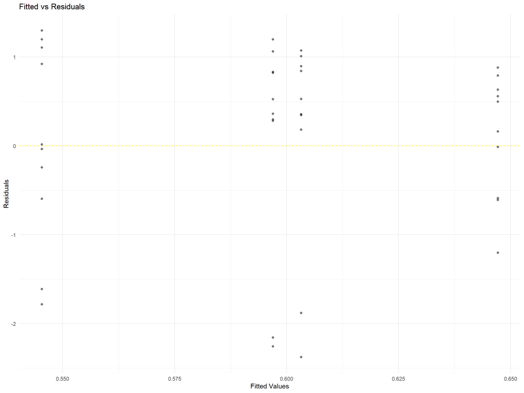

```
##
## Call:
## betareg(formula = simpson_index ~ Site * Time_Category, data = simpsonheight.unround)
##
## Quantile residuals:
##     Min      1Q  Median      3Q     Max
## -2.4437 -0.3134  0.2564  0.7435  1.2502
##
## Coefficients (mean model with logit link):
##                                      Estimate Std. Error z value Pr(>|z|)
## (Intercept)                           0.41895    0.26091   1.606    0.108
## SiteTurkey Brook                      0.18763    0.37055   0.506    0.613
## Time_CategoryBefore                  -0.02621    0.36783  -0.071    0.943
## SiteTurkey Brook:Time_CategoryBefore -0.39847    0.52109  -0.765    0.444
##
## Phi coefficients (precision model with identity link):
##       Estimate Std. Error z value Pr(>|z|)
## (phi)    4.918      1.011   4.862 1.16e-06 ***
## ---
## Signif. codes:  0 '***' 0.001 '**' 0.01 '*' 0.05 '.' 0.1 ' ' 1
##
## Type of estimator: ML (maximum likelihood)
## Log-likelihood: 9.335 on 5 Df
## Pseudo R-squared: 0.03521
## Number of iterations: 12 (BFGS) + 2 (Fisher scoring)
```

Since you may not be familiar with Beta regression, here are some basics on interpretation for the test output:

- Quantile residuals measure the difference between the actual data and predicted values. The median should be close to 0. Also check the residuals vs fitted plot to ensure there is no clear trend or unusual outliers
- Coefficients (mean model): these are the effects of the predictors (site, time) on the response variable (Simpson index). **Look for significant p values in the last column, particularly for the Site_____:Time_Category_____ row, which is the interaction term (if significant, this means the Simpson index changed over time differently between sites)**.
- Phi coefficients: there is a p-value here as well, but this refers to whether the spread of the data around the mean was an important feature. If the phi estimate is very high, this means the data was concentrated around the mean (Simpson index doesn’t fluctuate much between sites/times). Consider phi of 0.1 to be spread out data, 1 to be moderate, and 10 to be concentrated around the mean.
- Pseudo R-squared: this is how much of the variation in Simpson index can be explained by the site and time variables. Often low in ecological contexts.

If you are not confident in your interpretation of the Beta regression, we strongly recommend basing your interpretation on the metrics themselves, rather than what the various p-values might imply.

### Species Relative Abundance: Beta Regression

In the next chunk of code you can specify a particular species and a height class (or combine all height classes). A beta regression will then be run for that species (and height class) so that you can assess the statistical significance of the observed changes in relative abundance of that species at the restoration site compared with the control or reference site (i.e., the Site*Time interaction). The height class option is, as before, to allow you to assess species as a standard biological concept, or explore the different functions that we have assumed that different heights of plant can play.

As always, you should only run these tests if you have *a priori* hypotheses and predictions for the particular species, and should avoid the temptation to dredge through various species looking for any significant changes (which you would surely observe, just due to chance, if you look at a number of species).

```r
target_species <- "PHALARU"   # <-- add plant_code value for focal species
target_height <- "L"           # <-- define "C", "M", "L", or write "combo" for all height classes combined together
```

```
## $Combined
##
## Call:
## betareg(formula = abundance ~ Site * Time_Category, data = speciesbeta)
##
## Quantile residuals:
##     Min      1Q  Median      3Q     Max
## -1.9425 -0.7360 -0.3775  0.2737  2.3446
##
## Coefficients (mean model with logit link):
##                                      Estimate Std. Error z value Pr(>|z|)
## (Intercept)                           0.59410    0.35836   1.658   0.0973 .
## SiteTurkey Brook                      0.26946    0.50049   0.538   0.5903
## Time_CategoryBefore                  -0.05527    0.50062  -0.110   0.9121
## SiteTurkey Brook:Time_CategoryBefore  0.31544    0.70681   0.446   0.6554
##
## Phi coefficients (precision model with identity link):
##       Estimate Std. Error z value Pr(>|z|)
## (phi)   1.8808     0.3741   5.027 4.98e-07 ***
## ---
## Signif. codes:  0 '***' 0.001 '**' 0.01 '*' 0.05 '.' 0.1 ' ' 1
##
## Type of estimator: ML (maximum likelihood)
## Log-likelihood: 12.52 on 5 Df
## Pseudo R-squared: 0.03852
## Number of iterations: 21 (BFGS) + 1 (Fisher scoring)
```

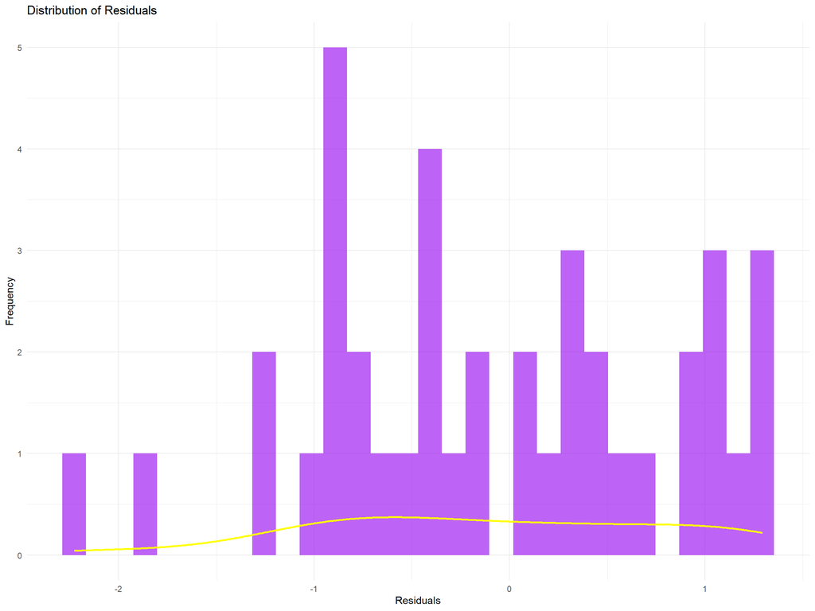

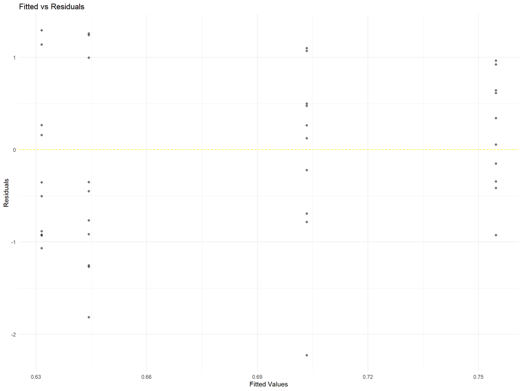

We will wrap up the relative abundance analysis for now. As a reminder, relative abundance measures of the composition of the cover, but does not provide information about the absolute amounts of cover. In most cases, the density of vegetation will also be of interest and, in our next section, we will explore cover densities of the vegetation overall and of each species.